# Pm10 in Italy

# Inferencial models

The main idea is to try to predict what will happen in Modena knowing what is going on in Bologna and Parma.

## Statistical approach

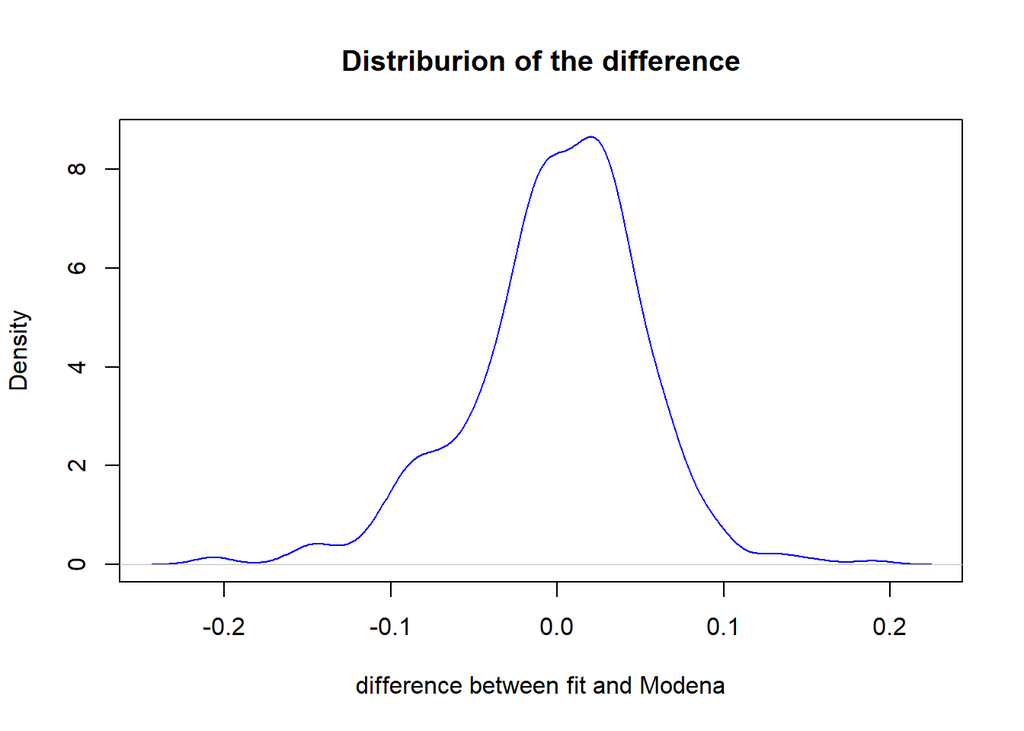

```r
# linear fit
linear_fit <- with(df_it_new, lm(Modena ~ Bologna + Parma, df_it_new))$coefficients


# plot difference
plot(density(linear_fit[1] + linear_fit[2]*df_it_new$Bologna + linear_fit[3]*df_it_new$Parma - df_it_new$Modena), pch = 20, col = 'blue', cex = 1 ,xlab = 'difference between fit and Modena', main = 'Distriburion of the difference')
```

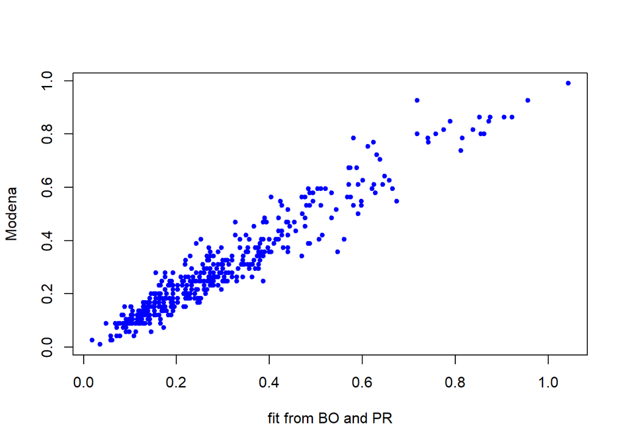

```r
# plot timeseries modena and fit
plot(linear_fit[1] + linear_fit[2]*df_it_new$Bologna + linear_fit[3]*df_it_new$Parma,df_it_new$Modena,   pch = 20, col = 'blue', cex = 1 , ylab = 'Modena', xlab = 'fit from BO and PR')
```

```r
# correlation
cor(linear_fit[1] + linear_fit[2]*df_it_new$Bologna + linear_fit[3]*df_it_new$Parma,df_it_new$Modena)
```

```
## [1] 0.961001
```

## Jags (linear model normal)

```r
set.seed(15944)
cat(
  "model {
  #model
  for (i in 1:N){
    return[i] ~ dnorm(mu[i], tau)
    mu[i] <- b0 + b1*Bologna[i] + b2*Parma[i]
  }

  #priors
  b0 ~ dnorm( 0 , 1.0E-12 )
  b1 ~ dnorm( 0 , 1.0E-12 )
  b2 ~ dnorm( 0 , 1.0E-12 )
  tau ~ dgamma(0.001, 0.001)
  # t0 ~ dnorm(0, 0.01)
  # phi <- exp(t0)
  }", file="linear.jag"
)
# Define data structure

dat1 = list(return = df_it_new$Modena, Bologna=df_it_new$Bologna, Parma=df_it_new$Parma, N=nrow(df_it_new))
# lapply(dat1,summary)

# Init list parameters for JAGS

inits<-list(
  list(b0=1.01, b1=1.01, b2=1.01, tau = 1),
  list(b0=0.9, b1=0.9, b2=0.9, tau= 0.5)
)
parameters<-c("b0", "b1", "b2", "tau")

# RUN JAGS
linear_model <- jags(data = dat1,  # DATA
                     inits = inits,  # MODEL
                     parameters.to.save = parameters,
                     model.file = "linear.jag",
                     n.chains = 2,
                     n.iter = 5000,
                     n.burnin = 2000,
                     n.thin = 10)
linear_model
```

[output not shown]

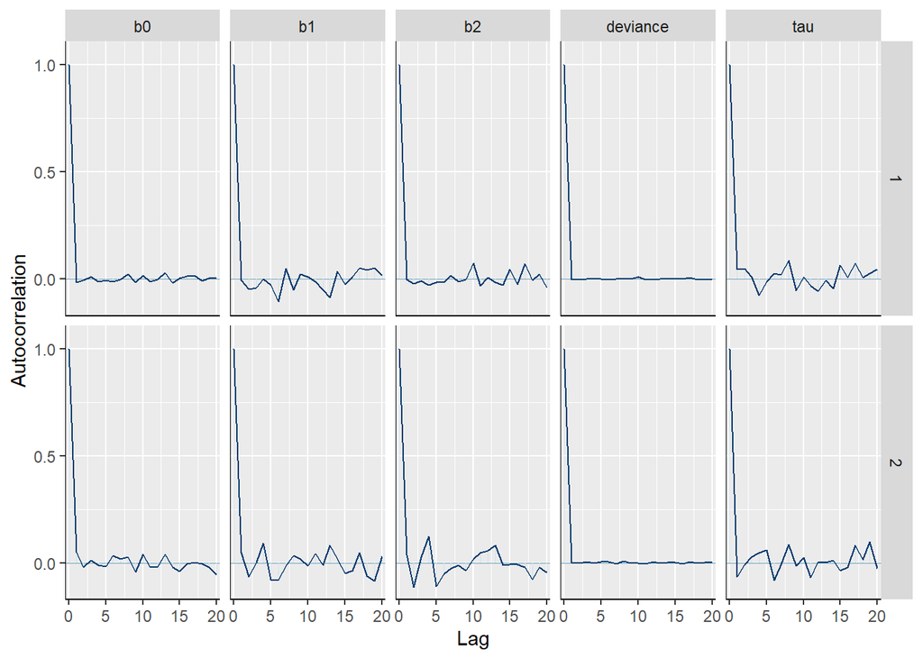

```r
chainArray<-linear_model$BUGSoutput$sims.array
bayesplot::mcmc_acf(chainArray)
```

```r
# Credible interval (HPD)

chainMat <- linear_model$BUGSoutput$sims.matrix
beta.HPD.jags <- coda::HPDinterval(as.mcmc(chainMat))
beta.HPD.jags
```

```
##                  lower         upper
## b0       -1.601972e-02  2.780951e-03
## b1        3.831038e-01  4.983938e-01
## b2        6.069915e-01  7.122072e-01
## deviance -1.398575e+03 -1.388881e+03
## tau       3.238019e+02  4.223376e+02
## attr(,"Probability")
## [1] 0.95
```

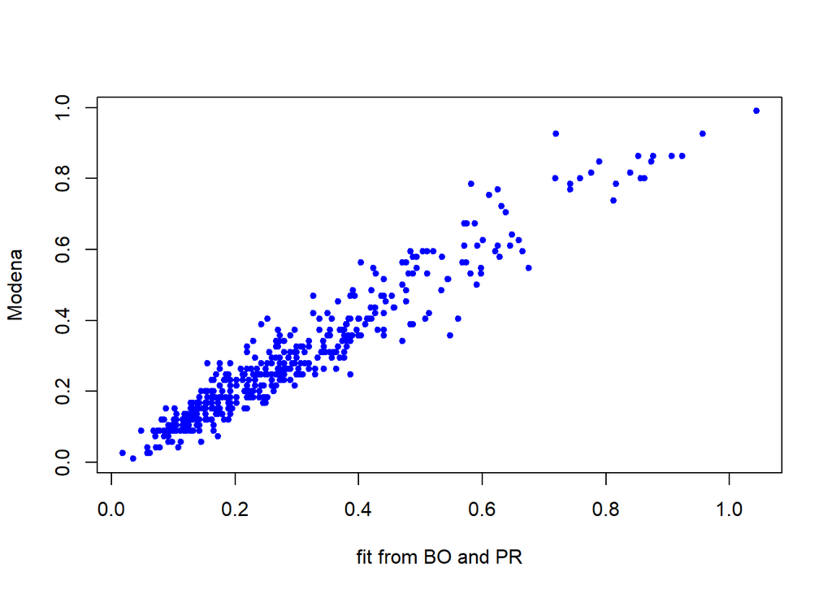

```r
# plot timeseries modena and fit
B0 <- mean(linear_model$BUGSoutput$sims.matrix[,1])
B1 <- mean(linear_model$BUGSoutput$sims.matrix[,2])
B2 <- mean(linear_model$BUGSoutput$sims.matrix[,3])

plot(B0 + B1*df_it_new$Bologna + B2*df_it_new$Parma,df_it_new$Modena,   pch = 20, col = 'blue', cex = 1 , ylab = 'Modena', xlab = 'fit from BO and PR')
```

```r
# correlation
cor(B0 + B1*df_it_new$Bologna + B2*df_it_new$Parma, df_it_new$Modena)
```

```
## [1] 0.9610003
```

# Dealing with missing values

The main problem of this dataset is the presence of some missing values and repeted values, in particular if I consider the whole italian dataset, of the median, whith all the values (pm10, pm25, co2,…), knowing that there are 11 cities and the dataset goes from 2018-12-31 to 2020-07-02 (550 days), the percentage of values compared to 6050 is:

```r
# split the dataset  by species
splitted_it <- split(df_it, df_it$Specie)
names_splitted <- attributes(splitted_it)

optimal_number <- 550*11 #6050

# for each one evaluate the number of missing values per city
percentage <- as.data.frame((table(df_it$Specie)))
percentage$Freq <- percentage$Freq/optimal_number

percentage[percentage$Freq != 0,]
```

```
##             Var1       Freq
## 2             co 0.91950413
## 3            dew 0.59090909
## 4       humidity 1.05735537
## 6            no2 0.90495868
## 7             o3 0.60330579
## 9           pm10 0.98462810
## 10          pm25 1.07570248
## 12 precipitation 0.02396694
## 13      pressure 1.05735537
## 14           so2 0.58429752
## 15   temperature 1.05735537
## 18     wind-gust 0.87685950
## 19    wind-speed 0.87603306
## 21     wind gust 0.16082645
## 22    wind speed 0.16165289
```

The fact that in some fields there are more values than 6050 do not imply that there are no missing values but only that there are repeted values, the same for the contrary.

The idea is to consider humidity, pm25, pressure and temperature to predict the value of pm10 in Modena. To do this I have to deal with missing values via Gibbs sampling.

## Build dataset

First of all let’s build the dataset.

```r
# select only modena
Modena <- df_it[df_it$City == 'Modena',]

All_species <- c("co","humidity","o3","pm25","so2","wind-gust","no2","pm10","pressure","temperature","wind-speed","dew","wind gust","wind speed")
All_species <- sort(All_species)


Modena_species <- c('pm10', 'humidity', 'pm25', 'pressure', 'temperature')

date <- df_it$Date[!duplicated(df_it$Date)]

Modena_new <- setNames(data.frame(matrix(ncol = length(All_species), nrow = 0)), All_species)
for (i in 1:length(date)){

  if (sum(Modena$Date == date[i]) == 0) {
    Modena_day_transpose <- setNames(data.frame(matrix(ncol = length(All_species), nrow = 1)), All_species)
    Modena_new <- smartbind(Modena_new, Modena_day_transpose)
  }
  else{
    Modena_day <- Modena[Modena$Date == date[i],c('Specie','median')]
    Modena_day <- Modena_day[order(Modena_day$Specie),]


    Modena_day <- Modena_day[!duplicated(Modena_day$Specie),]

    rownames(Modena_day) <- Modena_day$Specie
    Modena_day$Specie <- NULL
    Modena_day_transpose <- transpose(Modena_day)
    colnames(Modena_day_transpose) <- rownames(Modena_day)
    rownames(Modena_day_transpose) <- date[i]
    Modena_new <- smartbind(Modena_new, Modena_day_transpose)
  }
}
rownames(Modena_new) <- date
Modena_new <- Modena_new[Modena_species]


# convert in numeric
cols <- c(1, 2, 3, 4, 5);
Modena_new[,cols] <-  apply(Modena_new[,cols], 2,
                            as.numeric);

summary(Modena_new)
```

```
##       pm10          humidity          pm25           pressure
##  Min.   : 5.00   Min.   :18.20   Min.   : 13.00   Min.   : 987.1
##  1st Qu.:15.00   1st Qu.:49.00   1st Qu.: 38.00   1st Qu.:1008.6
##  Median :21.00   Median :62.50   Median : 53.00   Median :1012.5
##  Mean   :24.78   Mean   :64.07   Mean   : 60.68   Mean   :1012.5
##  3rd Qu.:30.00   3rd Qu.:81.58   3rd Qu.: 72.50   3rd Qu.:1016.9
##  Max.   :73.00   Max.   :98.00   Max.   :176.00   Max.   :1038.1
##  NA's   :29      NA's   :48      NA's   :38       NA's   :48
##   temperature
##  Min.   : 0.00
##  1st Qu.: 8.80
##  Median :14.55
##  Mean   :14.66
##  3rd Qu.:20.60
##  Max.   :30.50
##  NA's   :48
```

```r
# normalize everything
preproc2 <- preProcess(Modena_new, method=c("range"))
Modena_new <- predict(preproc2, Modena_new)
Modena_new<- Modena_new*0.98+0.01
summary(Modena_new)
```

```
##       pm10           humidity           pm25           pressure
##  Min.   :0.0100   Min.   :0.0100   Min.   :0.0100   Min.   :0.0100
##  1st Qu.:0.1541   1st Qu.:0.3882   1st Qu.:0.1603   1st Qu.:0.4236
##  Median :0.2406   Median :0.5540   Median :0.2505   Median :0.4981
##  Mean   :0.2951   Mean   :0.5734   Mean   :0.2967   Mean   :0.4973
##  3rd Qu.:0.3703   3rd Qu.:0.7883   3rd Qu.:0.3677   3rd Qu.:0.5821
##  Max.   :0.9900   Max.   :0.9900   Max.   :0.9900   Max.   :0.9900
##  NA's   :29       NA's   :48       NA's   :38       NA's   :48
##   temperature
##  Min.   :0.0100
##  1st Qu.:0.2928
##  Median :0.4775
##  Mean   :0.4811
##  3rd Qu.:0.6719
##  Max.   :0.9900
##  NA's   :48
```

```r
head(Modena_new)
```

```
##                 pm10  humidity      pm25  pressure temperature
## 2018-12-31 0.4711765 0.2936842 0.7675460 0.6767843  0.25740984
## 2019-01-01 0.4855882 0.8156140 0.8577301 0.7267451  0.06462295
## 2019-01-02 0.3270588 0.7566667 0.7555215 0.5672549  0.09675410
## 2019-01-03 0.2117647 0.2531579 0.5030061 0.6767843  0.08068852
## 2019-01-04 0.2117647 0.1856140 0.5150307 0.7113725  0.07426230
## 2019-01-05 0.5144118 0.4128070 0.8396933 0.6037647  0.08711475
```

```r
# to save it
# write.csv(Modena_new,"C:/Users/franc/Desktop/Data_science/SDS_2/SDS_2_Homeworks/project/project_SDS2/Modena_new.csv", row.names = TRUE)
```

```r
# after saving df_it_new I'm going to read directly it
Modena_new <- read.csv("C:/Users/franc/Desktop/Data_science/SDS_2/SDS_2_Homeworks/project/project_SDS2/Modena_new.csv", header = TRUE,row.names=1)
summary(Modena_new)
head(Modena_new)
```

## Illustration of the dataset whitout NA

```r
# remove NA's
Modena_new_nona <-  Modena_new[complete.cases(Modena_new), ]
```

### Timeseries plot

```r
Modena_species <- c('pm10', 'humidity', 'pm25', 'pressure', 'temperature')

par(mfrow=c(1,1))

for (i in 1:length(Modena_species)) {
  cat(sprintf('\n#### %s \n' ,Modena_species[i]))
  plot(Modena_new_nona[,i], main = Modena_species[i], xlab= 'days', ylab = 'pm10', pch = 20, col = 'blue', cex = 1)
  cat('\n')
}
```

#### pm10

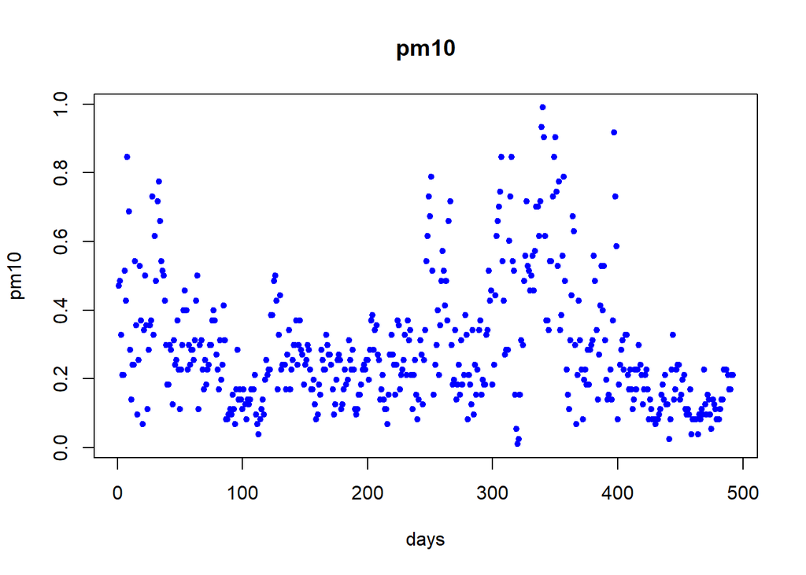

#### humidity

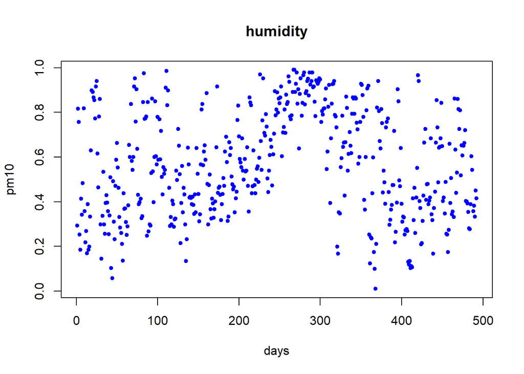

#### pm25

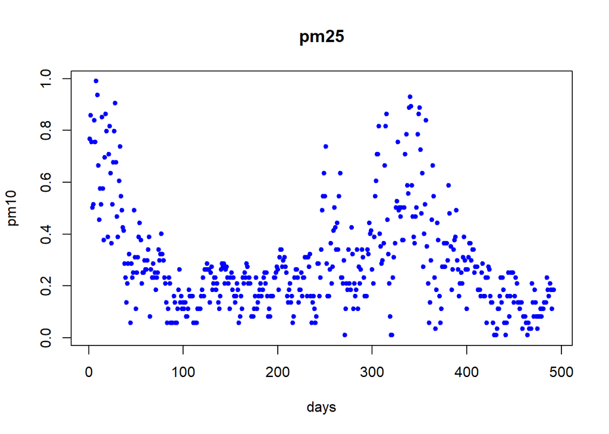

#### pressure

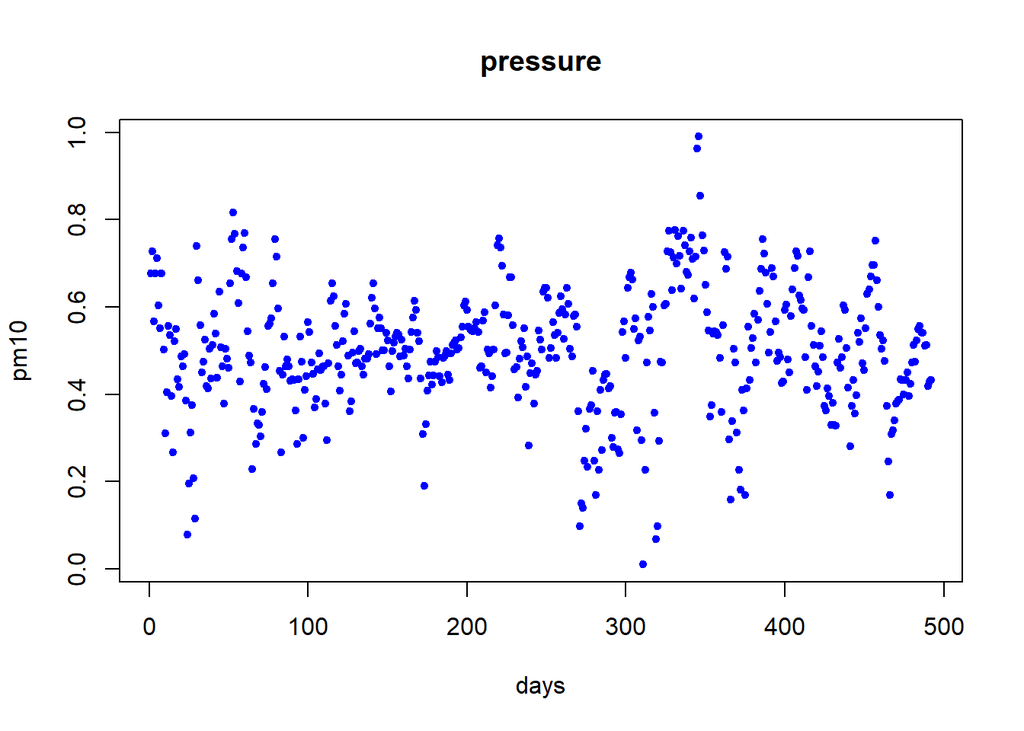

#### temperature

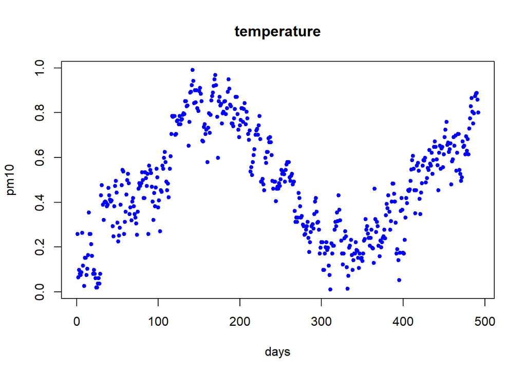

### Histograms

```r
Modena_species <- c('pm10', 'humidity', 'pm25', 'pressure', 'temperature')

# thanks to Cullen and Frey
distr_per_specie <- c('beta','beta','beta','normal','beta')

par(mfrow=c(1,2))


fitDISTR <- function(data, distr){
  if (distr == 'beta'){
    a <- fitdistr(data, densfun = 'beta',list(shape1=1, shape2=5))
  }
  else {
    a <- fitdistr(data, densfun = distr)
  }

  return(a)
}

for (i in 1:length(Modena_species)){
  cat(sprintf('\n#### %s \n' ,Modena_species[i]))
  hist(Modena_new_nona[,i], prob=T, xlab = 'pm10', main = paste(Modena_species[i],'(',distr_per_specie[i],')'), nclass = 20)
  # #lines(density(df_it_new[,i]), col='red', lwd=2)
  a <- fitDISTR(Modena_new_nona[,i],distr_per_specie[i])
  # #b <- fitdistr(df_it_new[,i], densfun = 'beta',list(shape1=1, shape2=5))
  #
  curve((distr_per_specie[i] == 'beta')*dbeta(x, shape1 =a$estimate[1], shape2=a$estimate[2])+
        (distr_per_specie[i] == 'normal')*dnorm(x, a$estimate[1], a$estimate[2]), col='blue', lwd=3, add=TRUE)
  # #curve(dbeta(x, shape1 =b$estimate[1], shape2=b$estimate[2]), col='red', lwd=3, add=TRUE)

  descdist(Modena_new_nona[,i], discrete = FALSE,boot=1000)
  cat('\n')
  }
```

#### pm10

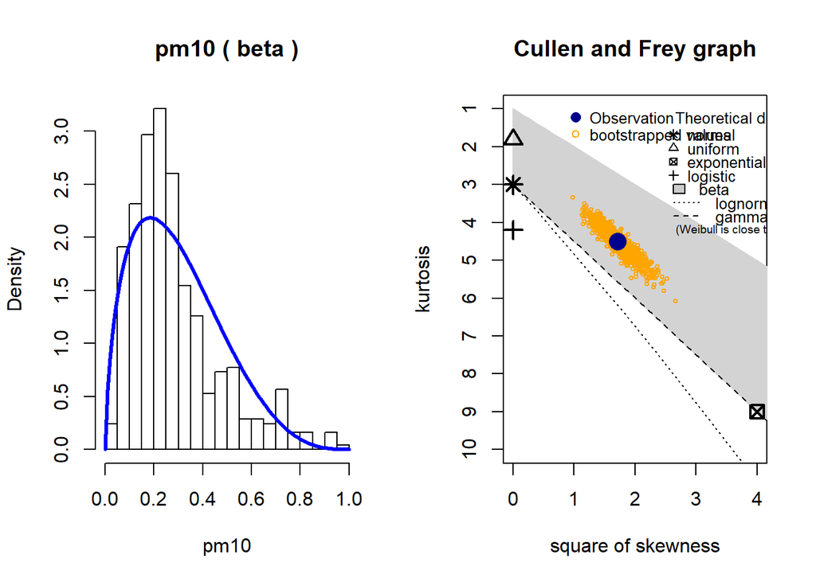

#### humidity

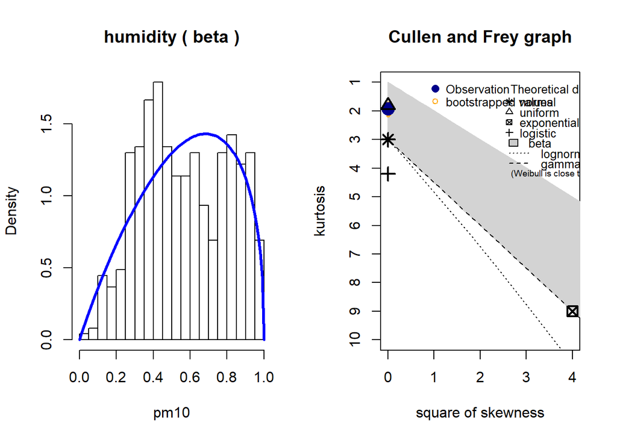

#### pm25

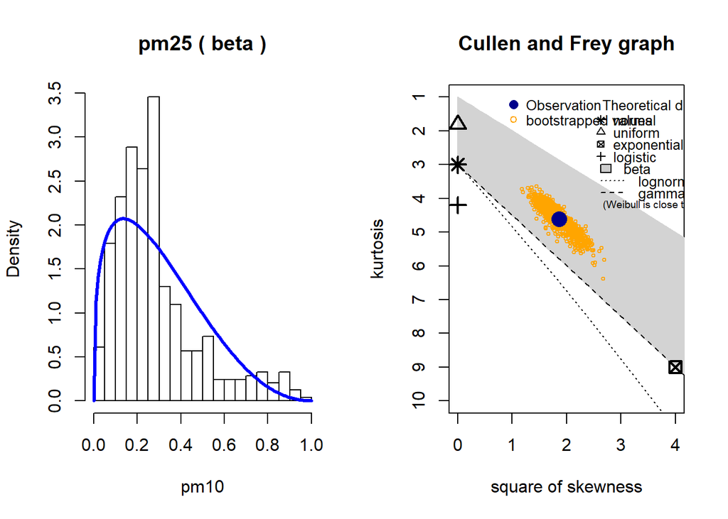

#### pressure

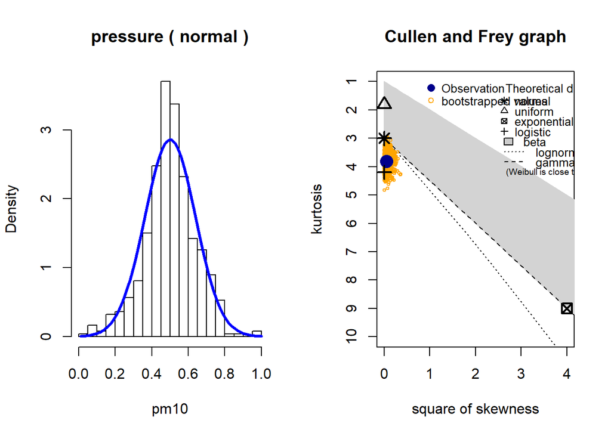

#### temperature

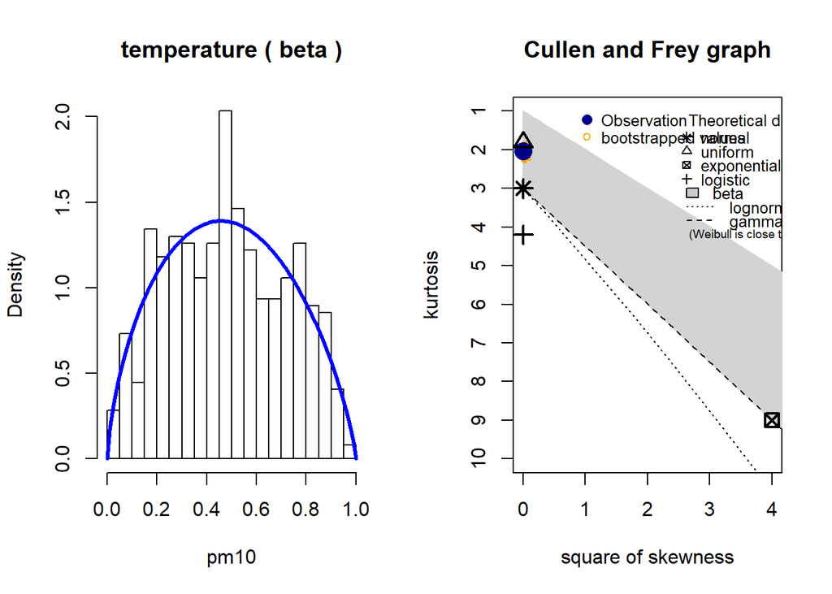

### Correlation

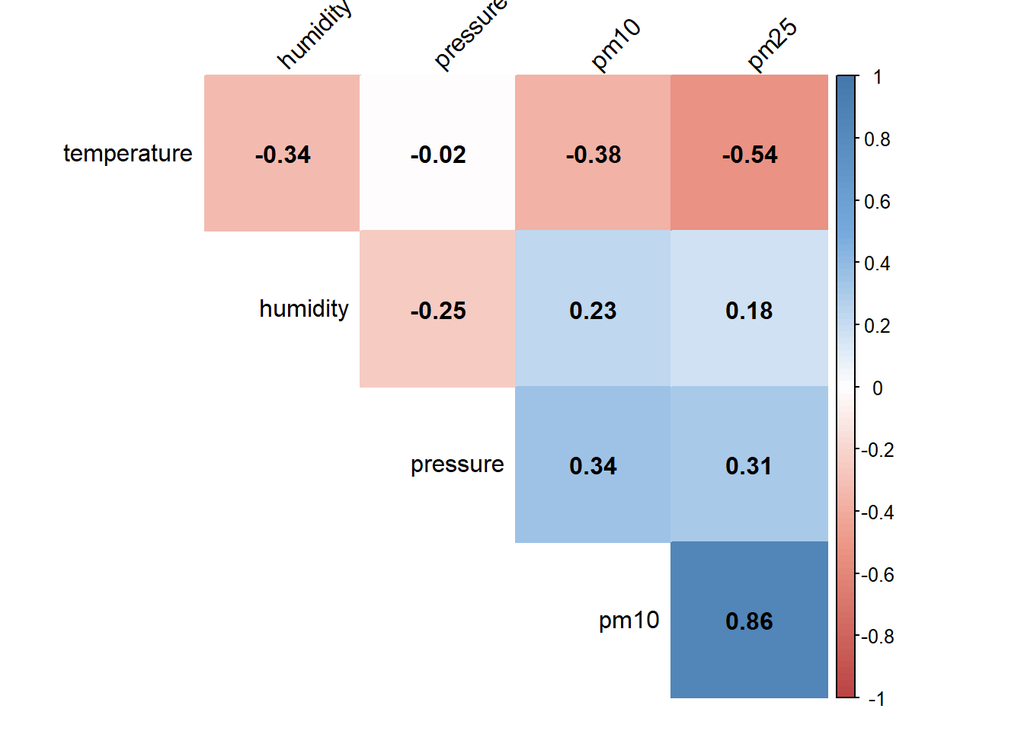

```r
par(mfrow=c(1,1))
M <-cor(Modena_new_nona)
col <- colorRampPalette(c("#BB4444", "#EE9988", "#FFFFFF", "#77AADD", "#4477AA"))
corrplot(M, method="color", col=col(100),
         type="upper", order="hclust",
         addCoef.col = "black", # Add coefficient of correlation
         tl.col="black", tl.srt=45, #Text label color and rotation
         # Combine with significance
         #p.mat = p.mat,
         #sig.level = 0.41,
         #insig = "blank",
         # hide correlation coefficient on the principal diagonal
         diag=FALSE
)
```

### Autocorrelation

```r
Modena_species <- c('pm10', 'humidity', 'pm25', 'pressure', 'temperature')
par(mfrow=c(1,1))

for (i in 1:length(Modena_species)){
  cat(sprintf('\n#### %s \n' ,Modena_species[i]))
  AutoCorrelation <- acf(Modena_new_nona[,i], plot = FALSE)
  plot(AutoCorrelation, main = Modena_species[i])
  cat('\n')
}
```

#### pm10

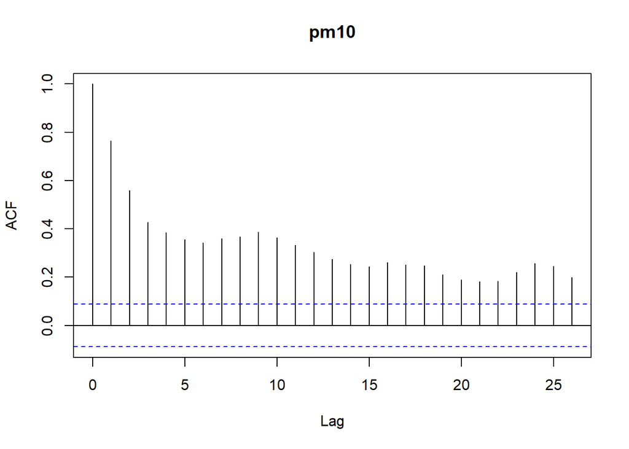

#### humidity

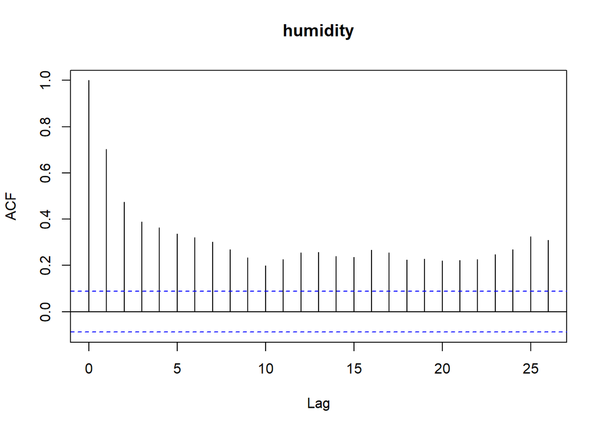

#### pm25

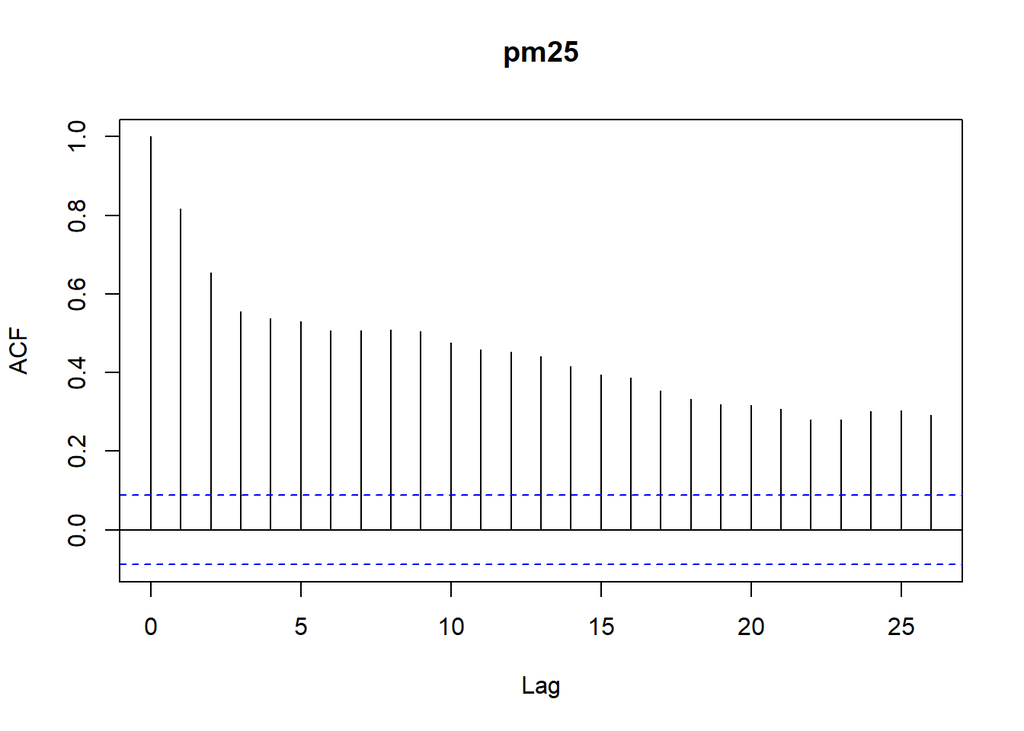

#### pressure

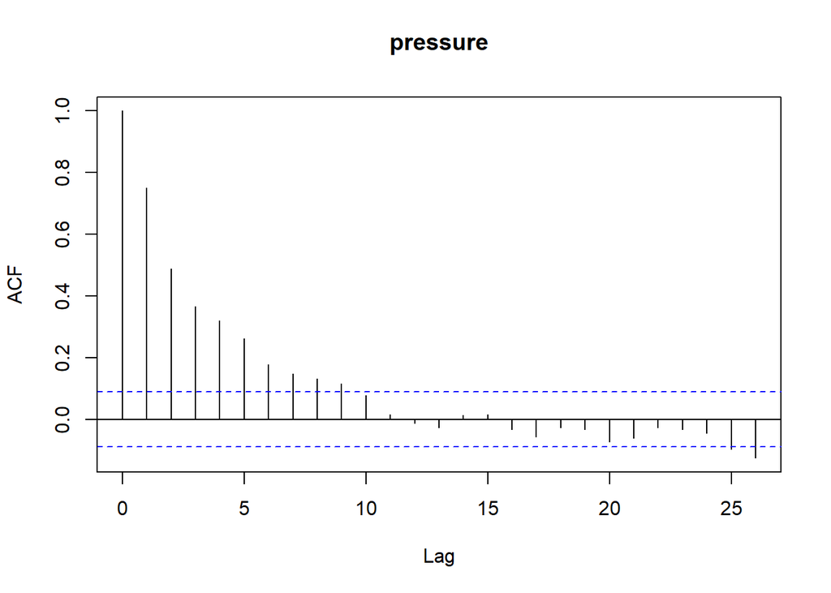

#### temperature

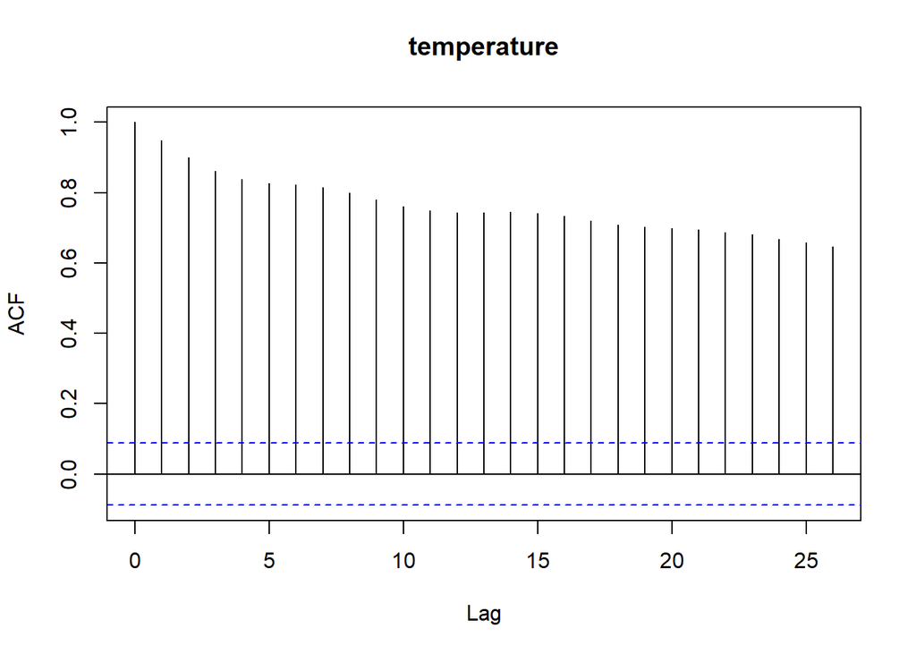

## Missing values sampling via Metropolis Hasting

Now I have to generate the missing values: the idea is to use a Gibb sampling algorithm to do it.

```r
# prova credente

par_1_d <- function(par_1){
  dnorm(par_1, prior_mean_par_1, prior_std_par_1)
}

par_2_d <- function(par_2){
  dnorm(par_2, prior_mean_par_2, prior_std_par_2)
}


Y_i <- function(y, par_1, par_2, type_d){
  if (type_d == 'beta'){
    dbeta(y, par_1, par_2)
  }
  else{
    dnorm(y, par_1, par_2)
  }
}


lik <- function(Y_obs, par_1, par_2, type_d){
  if (type_d == 'beta'){
    length(Y_obs)*log(beta(par_1, par_2)) + (par_1 - 1)* sum(log(Y_obs))
    + (par_2 - 1)* sum(log(1- Y_obs))
  }
  else{
   - (1/(2*par_2^2))*sum((Y_obs-par_1)^2)
  }
}



initial_param <- function(type_d){
  if (type_d == 'normal'){
    # normal
    prior_mean_par_1 <- mean(Y_obs)
    prior_mean_par_2 <- sd(Y_obs)
    return(c(prior_mean_par_1,prior_mean_par_2))
  }
  else{
    # beta
    return(fitdistr(Y_obs, densfun = 'beta',list(shape1=1, shape2=5))$estimate)
  }
}

Modena_new_imput <- copy(Modena_new)

for (col in 1:length(Modena_species)){
  Y_obs <- Modena_new_nona[,col]
  type_d <- distr_per_specie[col]
  prior_std_par_1 <- 0.01
  prior_std_par_2 <- 0.01
  mu <- initial_param(type_d)
  prior_mean_par_1 <- mu[1]
  prior_mean_par_2 <- mu[2]


  n_sim_aux <- length(Modena_new_imput[,col]) #total lenght

  missing_prediction <- rep(NA, n_sim_aux)
  par_1_seq <- rep(NA, n_sim_aux)
  par_2_seq <- rep(NA, n_sim_aux)

  missing_prediction[1] <- Y_obs[1]
  par_1_seq[1] <- prior_mean_par_1
  par_2_seq[1] <- prior_mean_par_2

  for (i in 2:n_sim_aux){
    proposed_par_1 <- rnorm(1, prior_mean_par_1, prior_std_par_1)
    proposed_par_2 <- rnorm(1, prior_mean_par_2, prior_std_par_2)

    N_pos <- exp(lik(Y_obs, proposed_par_1, proposed_par_2,type_d))*par_1_d(proposed_par_1)*par_2_d(proposed_par_2)

    D_pos <- exp(lik(Y_obs, par_1_seq[i-1], par_2_seq[i-1],type_d))*par_1_d(par_1_seq[i-1])*par_2_d(par_2_seq[i-1])

    N_pr <- dnorm(par_1_seq[i-1], prior_mean_par_1, prior_std_par_1)* dnorm(par_2_seq[i-1], prior_mean_par_2, prior_std_par_2)

    D_pr <- dnorm(proposed_par_1,  prior_mean_par_1, prior_std_par_1)*dnorm(proposed_par_2,  prior_mean_par_2, prior_std_par_2)

    a <- min((N_pos*N_pr)/(D_pos*D_pr), 1)


    old_or_new <- rbinom(1, size = 1, prob = c(a, 1-a))

    par_1_seq[i] <- ifelse(old_or_new, proposed_par_1,par_1_seq[i-1])
    par_2_seq[i] <- ifelse(old_or_new, proposed_par_2,par_2_seq[i-1])



    missing_prediction[i] <- (type_d == 'normal')*rnorm(1, par_1_seq[i],
                                                      par_2_seq[i]) +
                              (type_d == 'beta')*rbeta(1, par_1_seq[i],
                                                       par_2_seq[i])

    }


  # replace all NA
  change_these <- is.na(Modena_new_imput[,col])*missing_prediction
  # replace NA's with zeros and add those
  Modena_new_imput[,col][is.na(Modena_new_imput[,col])] <- 0.01
  Modena_new_imput[,col] <- Modena_new_imput[,col] + change_these

  }

summary(Modena_new_imput)
```

```
##       pm10           humidity           pm25           pressure
##  Min.   :0.0100   Min.   :0.0100   Min.   :0.0100   Min.   :0.0100
##  1st Qu.:0.1541   1st Qu.:0.3882   1st Qu.:0.1603   1st Qu.:0.4232
##  Median :0.2406   Median :0.5491   Median :0.2505   Median :0.4981
##  Mean   :0.2957   Mean   :0.5699   Mean   :0.2955   Mean   :0.4994
##  3rd Qu.:0.3703   3rd Qu.:0.7831   3rd Qu.:0.3767   3rd Qu.:0.5884
##  Max.   :0.9900   Max.   :0.9900   Max.   :0.9900   Max.   :0.9900
##   temperature
##  Min.   :0.0100
##  1st Qu.:0.2928
##  Median :0.4791
##  Mean   :0.4824
##  3rd Qu.:0.6719
##  Max.   :0.9900
```

### Illustration of the dataset after imputing

#### Timeseries plot

```r
Modena_species <- c('pm10', 'humidity', 'pm25', 'pressure', 'temperature')

par(mfrow=c(1,1))

for (i in 1:length(Modena_species)) {
  cat(sprintf('\n##### %s \n' ,Modena_species[i]))
  plot(Modena_new_imput[,i], main = Modena_species[i], xlab= 'days', ylab = 'pm10', pch = 20, col = 'blue', cex = 1)
  cat('\n')
}
```

##### pm10

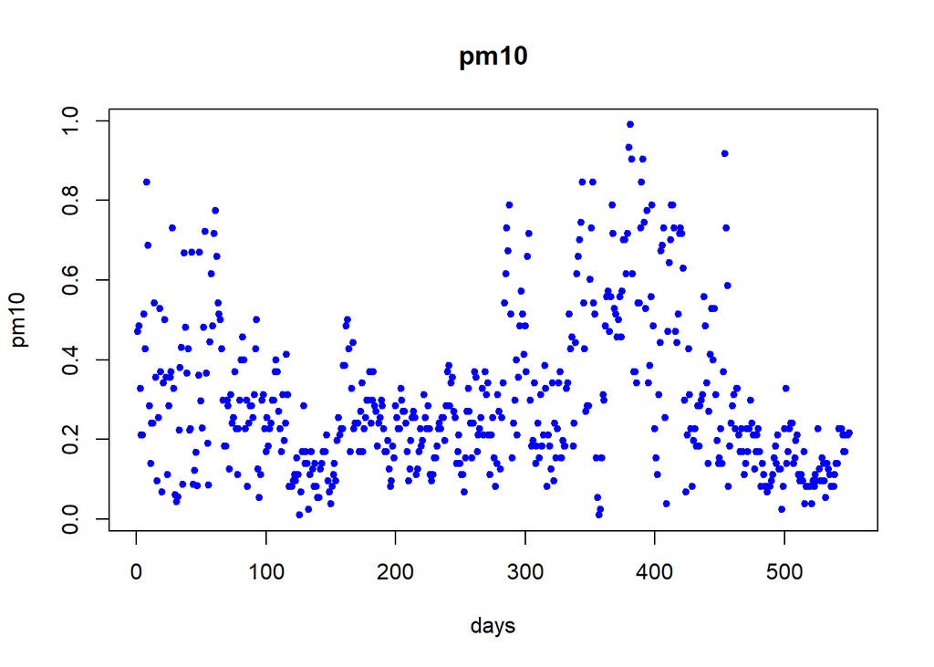

##### humidity

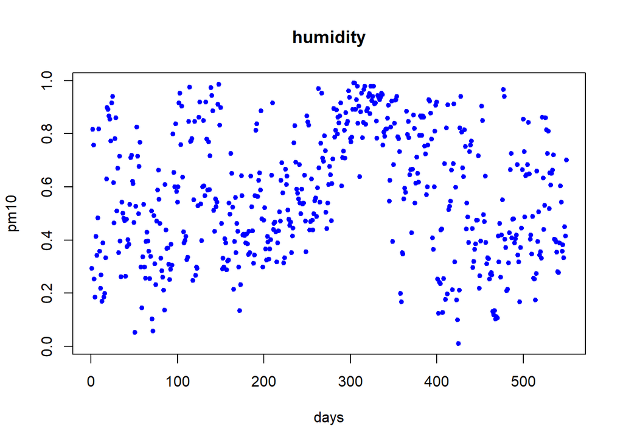

##### pm25

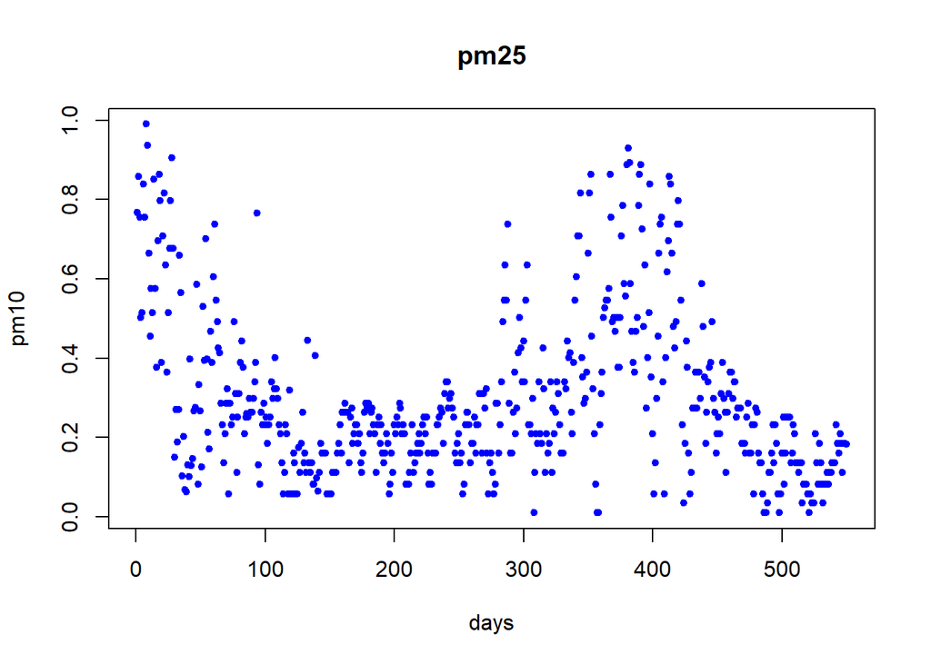

##### pressure

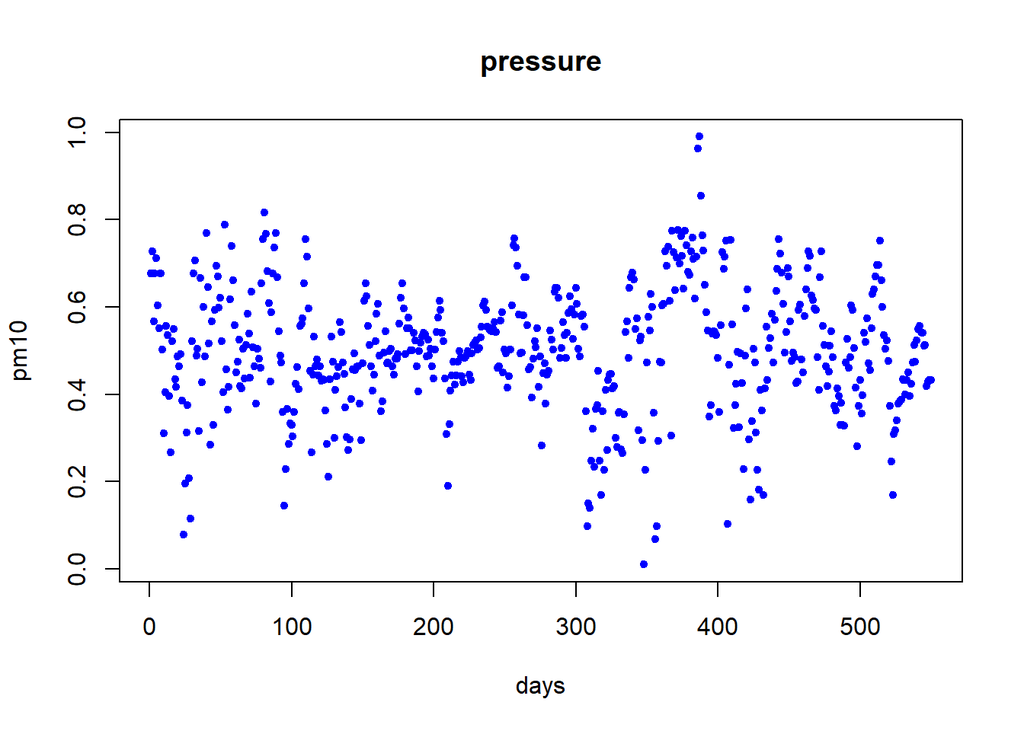

##### temperature

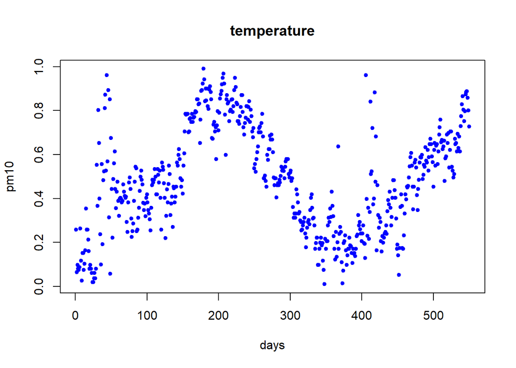

#### Histograms

```r
Modena_species <- c('pm10', 'humidity', 'pm25', 'pressure', 'temperature')

# thanks to Cullen and Frey
distr_per_specie <- c('beta','beta','beta','normal','beta')

par(mfrow=c(1,2))


fitDISTR <- function(data, distr){
  if (distr == 'beta'){
    a <- fitdistr(data, densfun = 'beta',list(shape1=1, shape2=5))
  }
  else {
    a <- fitdistr(data, densfun = distr)
  }

  return(a)
}

for (i in 1:length(Modena_species)){
  cat(sprintf('\n##### %s \n' ,Modena_species[i]))
  hist(Modena_new_imput[,i], prob=T, xlab = 'pm10', main = paste(Modena_species[i],'(',distr_per_specie[i],')'), nclass = 20)
  # #lines(density(df_it_new[,i]), col='red', lwd=2)
  a <- fitDISTR(Modena_new_imput[,i],distr_per_specie[i])
  # #b <- fitdistr(df_it_new[,i], densfun = 'beta',list(shape1=1, shape2=5))
  #
  curve((distr_per_specie[i] == 'beta')*dbeta(x, shape1 =a$estimate[1], shape2=a$estimate[2])+
        (distr_per_specie[i] == 'normal')*dnorm(x, a$estimate[1], a$estimate[2]), col='blue', lwd=3, add=TRUE)
  # #curve(dbeta(x, shape1 =b$estimate[1], shape2=b$estimate[2]), col='red', lwd=3, add=TRUE)

  descdist(Modena_new_imput[,i], discrete = FALSE,boot=1000)
  cat('\n')
  }
```

##### pm10

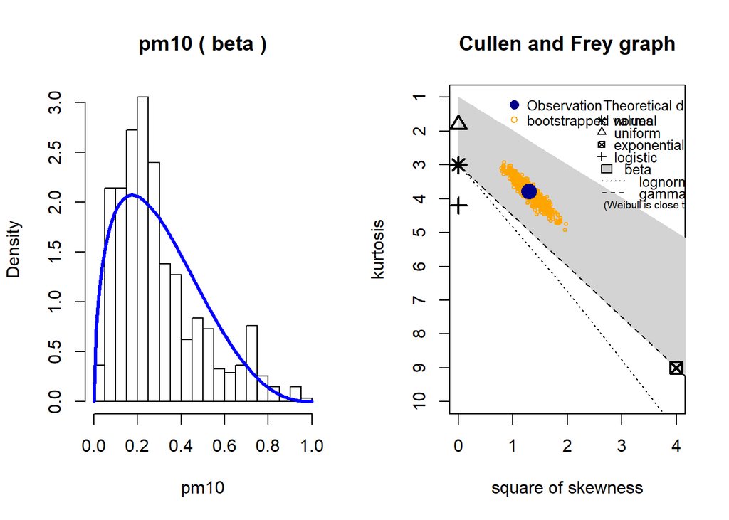

##### humidity

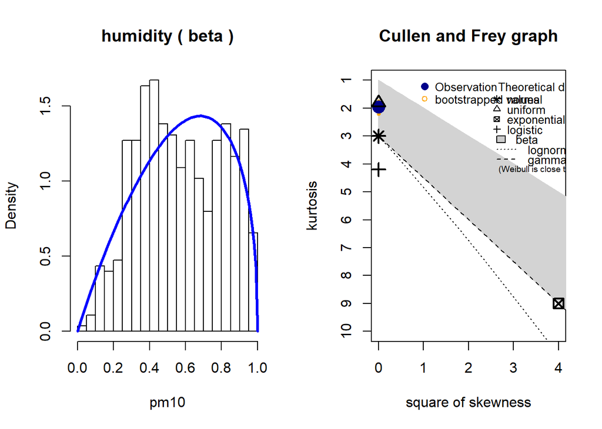

##### pm25

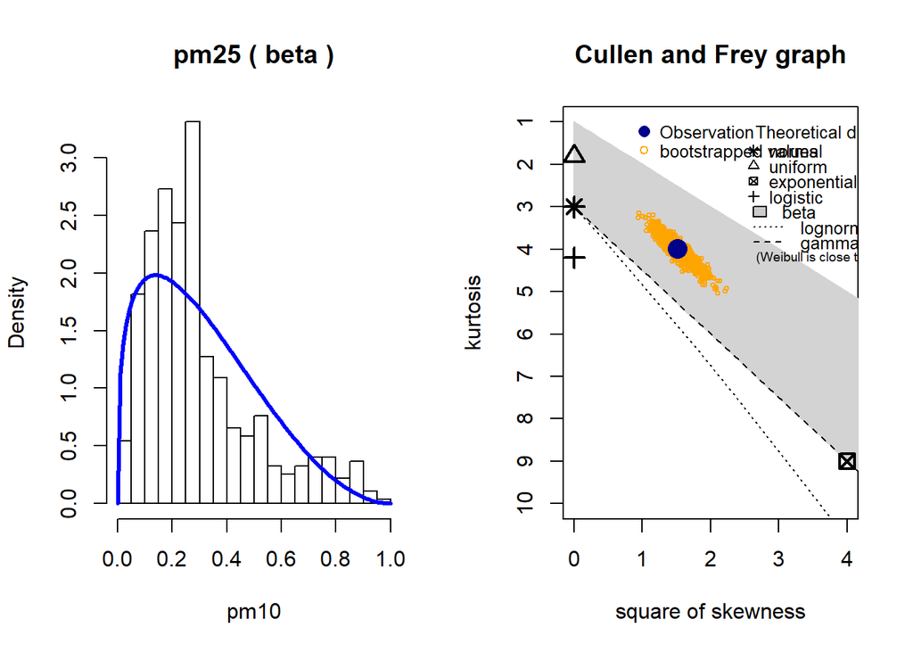

##### pressure

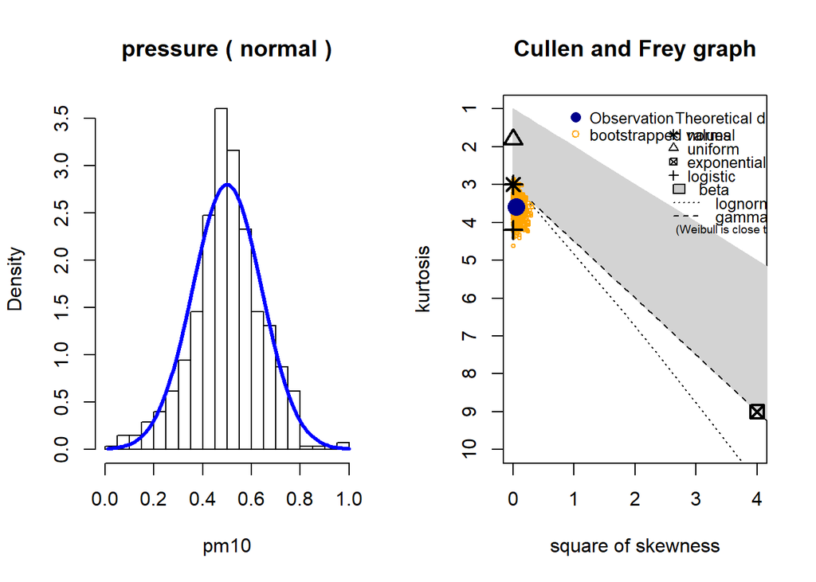

##### temperature

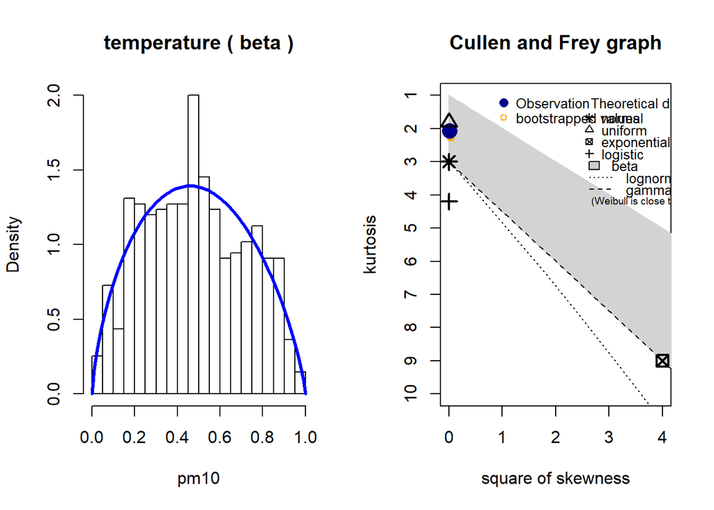

#### Correlation

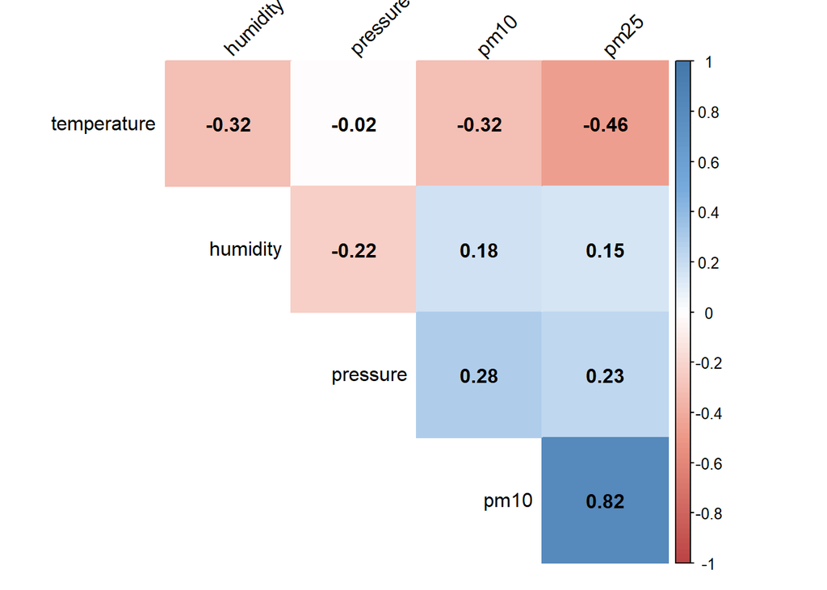

```r
par(mfrow=c(1,1))
M <-cor(Modena_new_imput)
col <- colorRampPalette(c("#BB4444", "#EE9988", "#FFFFFF", "#77AADD", "#4477AA"))
corrplot(M, method="color", col=col(100),
         type="upper", order="hclust",
         addCoef.col = "black", # Add coefficient of correlation
         tl.col="black", tl.srt=45, #Text label color and rotation
         # Combine with significance
         #p.mat = p.mat,
         #sig.level = 0.41,
         #insig = "blank",
         # hide correlation coefficient on the principal diagonal
         diag=FALSE
)
```

#### Autocorrelation

```r
Modena_species <- c('pm10', 'humidity', 'pm25', 'pressure', 'temperature')
par(mfrow=c(1,1))

for (i in 1:length(Modena_species)){
  cat(sprintf('\n##### %s \n' ,Modena_species[i]))
  AutoCorrelation <- acf(Modena_new_imput[,i], plot = FALSE)
  plot(AutoCorrelation, main = Modena_species[i])
  cat('\n')
}
```

##### pm10

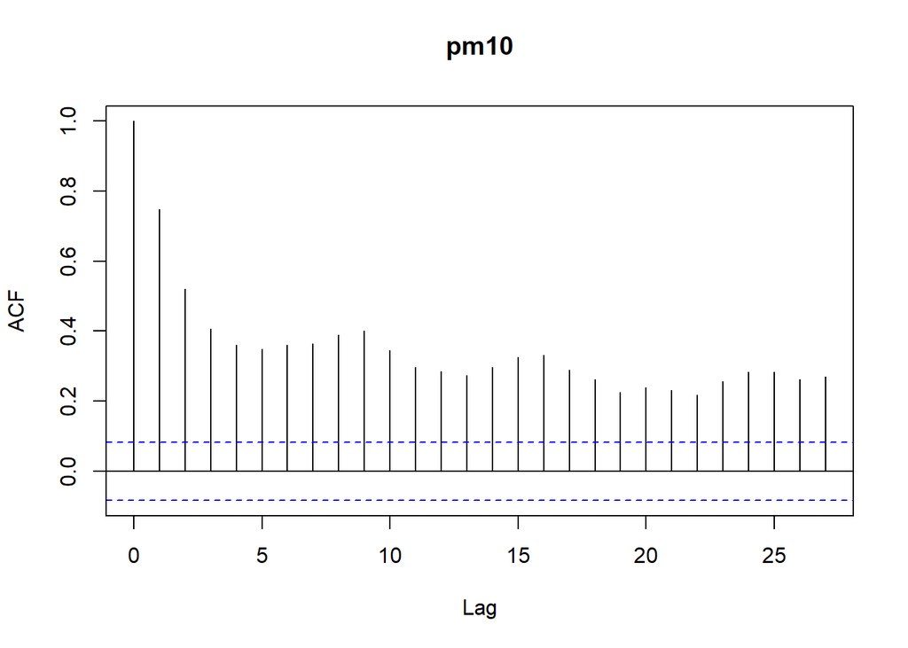

##### humidity

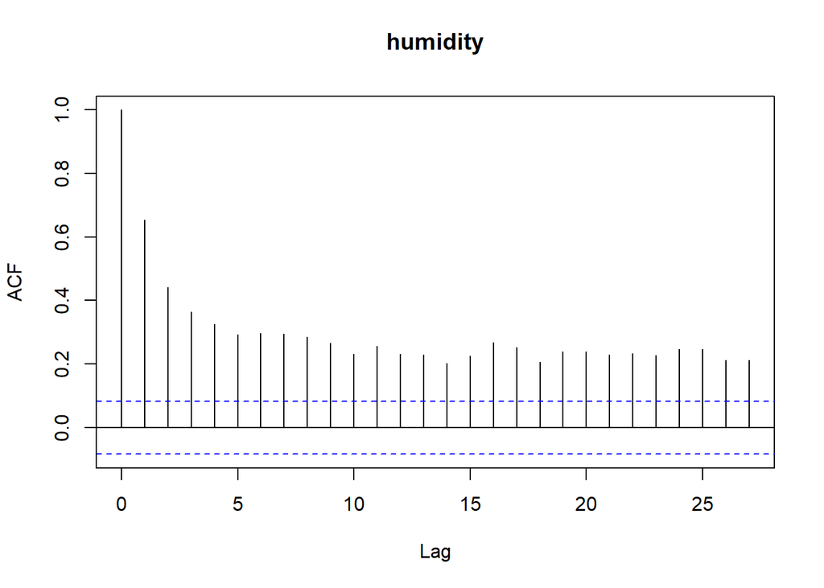

##### pm25

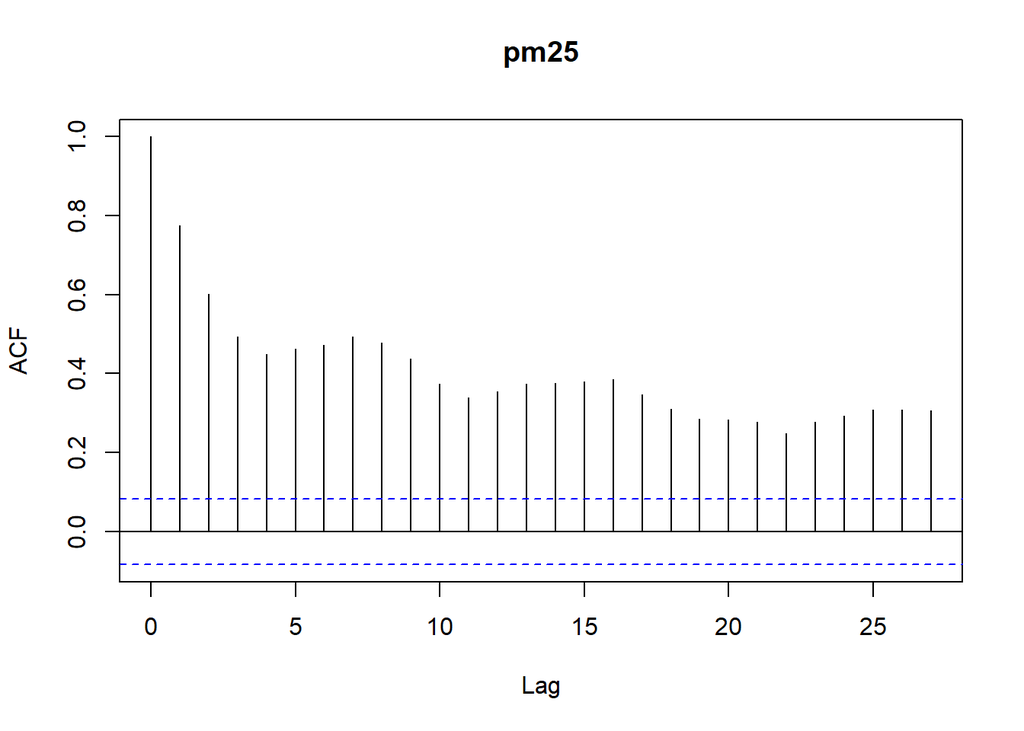

##### pressure

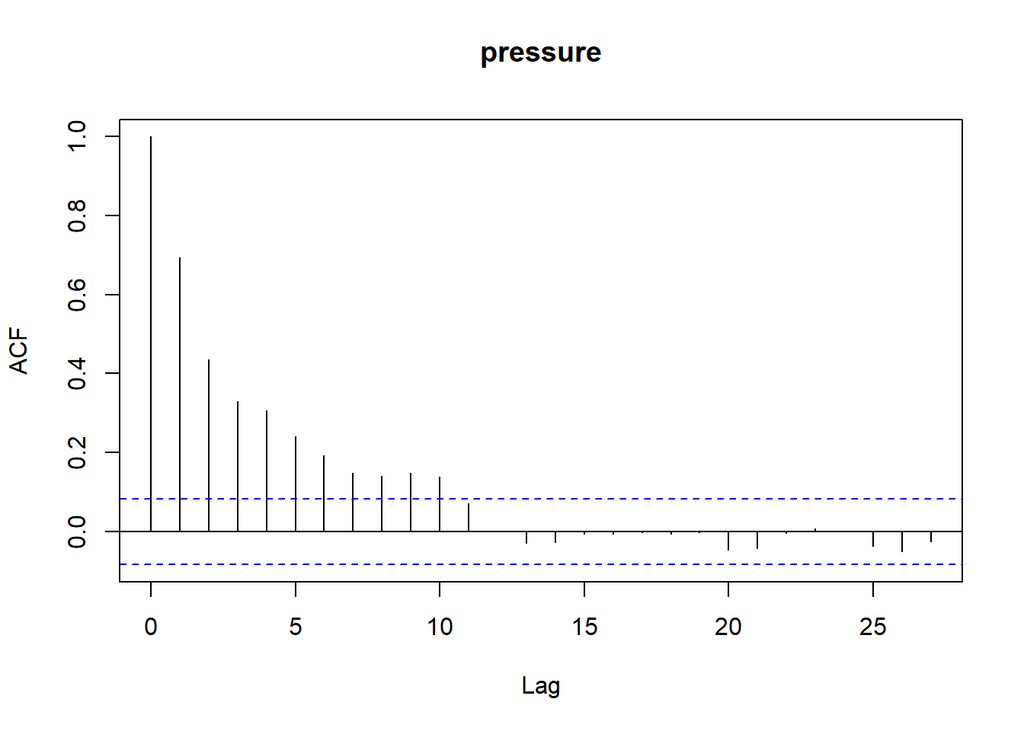

##### temperature

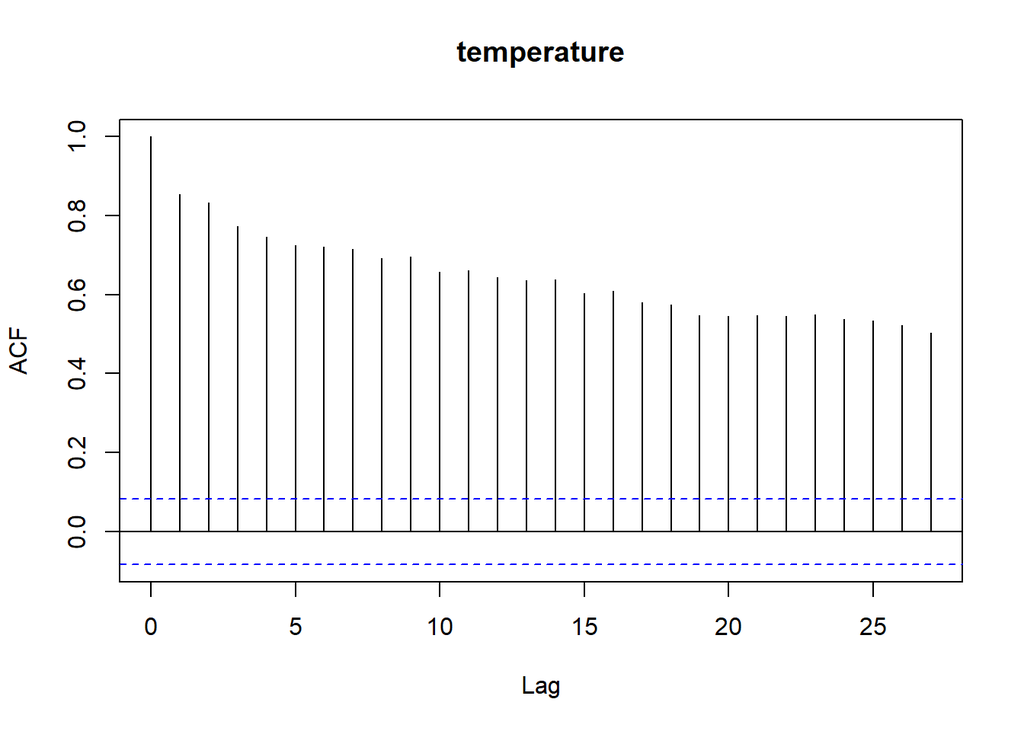

## Inferencial models

The main idea is to try to predict what will happen for pm10 in Modena knowing what is going on with pm25, temperature and pressure.

### Statistical approach

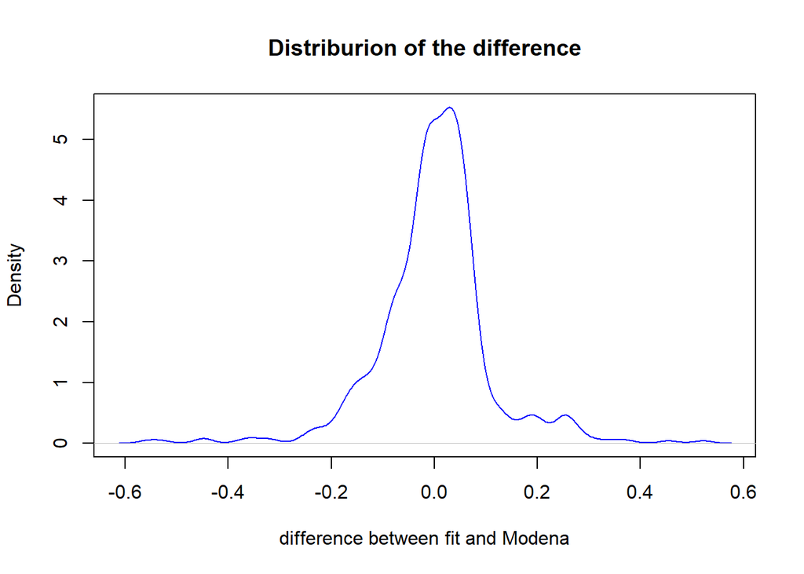

```r
# linear fit
linear_fit <- with(Modena_new_imput, lm(pm10 ~ pm25 + temperature + pressure, Modena_new_imput))$coefficients


# plot difference
plot(density(linear_fit[1] + linear_fit[2]*Modena_new_imput$pm25 + linear_fit[3]*Modena_new_imput$temperature + linear_fit[4]*Modena_new_imput$pressure - Modena_new_imput$pm10), pch = 20, col = 'blue', cex = 1 ,xlab = 'difference between fit and Modena', main = 'Distriburion of the difference')
```

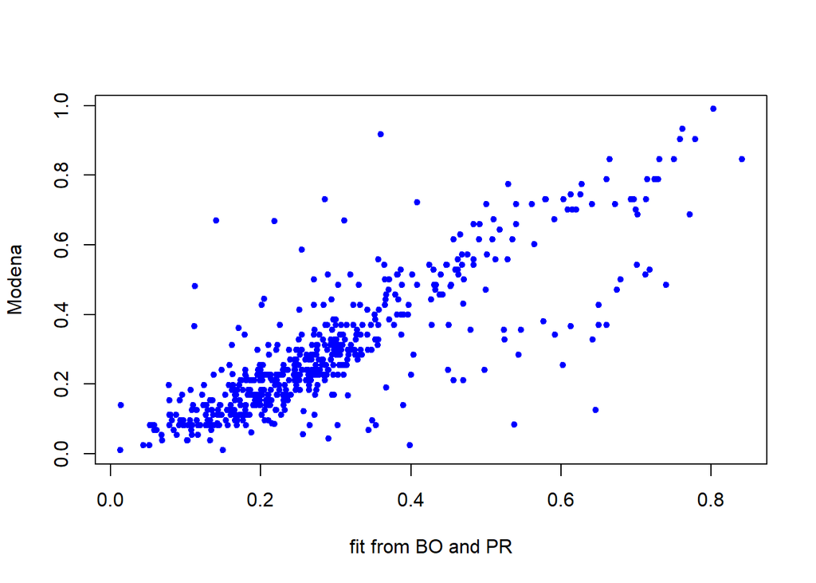

```r
# plot timeseries modena and fit
plot(linear_fit[1] + linear_fit[2]*Modena_new_imput$pm25 + linear_fit[3]*Modena_new_imput$temperature + linear_fit[4]*Modena_new_imput$pressure, Modena_new_imput$pm10,   pch = 20, col = 'blue', cex = 1 , ylab = 'Modena', xlab = 'fit from BO and PR')
```

```r
cor(linear_fit[1] + linear_fit[2]*Modena_new_imput$pm25 + linear_fit[3]*Modena_new_imput$temperature + linear_fit[4]*Modena_new_imput$pressure, Modena_new_imput$pm10)
```

```
## [1] 0.8270181
```

### Jags (linear model normal)

```r
set.seed(13579)
cat(
  "model {
  #model
  for (i in 1:N){
    return[i] ~ dnorm(mu[i], tau)
    mu[i] <- b0 + b1*pm25[i] - b2*temperature[i] + b3*pressure[i]
  }

  #priors
  b0 ~ dnorm( 0 , 1.0E-12 )
  b1 ~ dnorm( 0 , 1.0E-12 )
  b2 ~ dnorm( 0 , 1.0E-12 )
  b3 ~ dnorm( 0 , 1.0E-12 )
  tau ~ dgamma(0.001, 0.001)
  }", file="linear.jag"
)
# Define data structure

dat1 = list(return = Modena_new_imput$pm10, pm25=Modena_new_imput$pm25, temperature=Modena_new_imput$temperature,pressure=Modena_new_imput$pressure, N=nrow(Modena_new_imput))
# lapply(dat1,summary)

# Init list parameters for JAGS

inits<-list(
  list(b0=1.01, b1=1.01, b2=1.01, b3 = 1.01, tau = 1),
  list(b0=0.9, b1=0.9, b2=0.9, b3=0.9, tau= 0.5)
)
parameters<-c("b0", "b1", "b2", "b3", "tau")

# RUN JAGS
linear_model <- jags(data = dat1,  # DATA
                     inits = inits,  # MODEL
                     parameters.to.save = parameters,
                     model.file = "linear.jag",
                     n.chains = 2,
                     n.iter = 5000,
                     n.burnin = 2000,
                     n.thin = 10)
linear_model
```

```
## Inference for Bugs model at "linear.jag", fit using jags,
##  2 chains, each with 5000 iterations (first 2000 discarded), n.thin = 10
##  n.sims = 600 iterations saved
##           mu.vect sd.vect     2.5%      25%      50%      75%    97.5%  Rhat
## b0         -0.027   0.027   -0.068   -0.042   -0.026   -0.013    0.014 1.021
## b1          0.785   0.028    0.737    0.766    0.785    0.803    0.835 1.006
## b2         -0.058   0.025   -0.099   -0.073   -0.060   -0.044   -0.011 1.000
## b3          0.126   0.040    0.061    0.100    0.128    0.149    0.196 1.011
## tau        82.695   5.120   73.462   79.596   82.583   85.779   92.606 1.000
## deviance -867.929  15.883 -873.025 -871.040 -869.447 -867.388 -860.395 1.028
##          n.eff
## b0         600
## b1         600
## b2         600
## b3         600
## tau        600
## deviance   600
##
## For each parameter, n.eff is a crude measure of effective sample size,
## and Rhat is the potential scale reduction factor (at convergence, Rhat=1).
##
## DIC info (using the rule, pD = var(deviance)/2)
## pD = 126.3 and DIC = -741.6
## DIC is an estimate of expected predictive error (lower deviance is better).
```

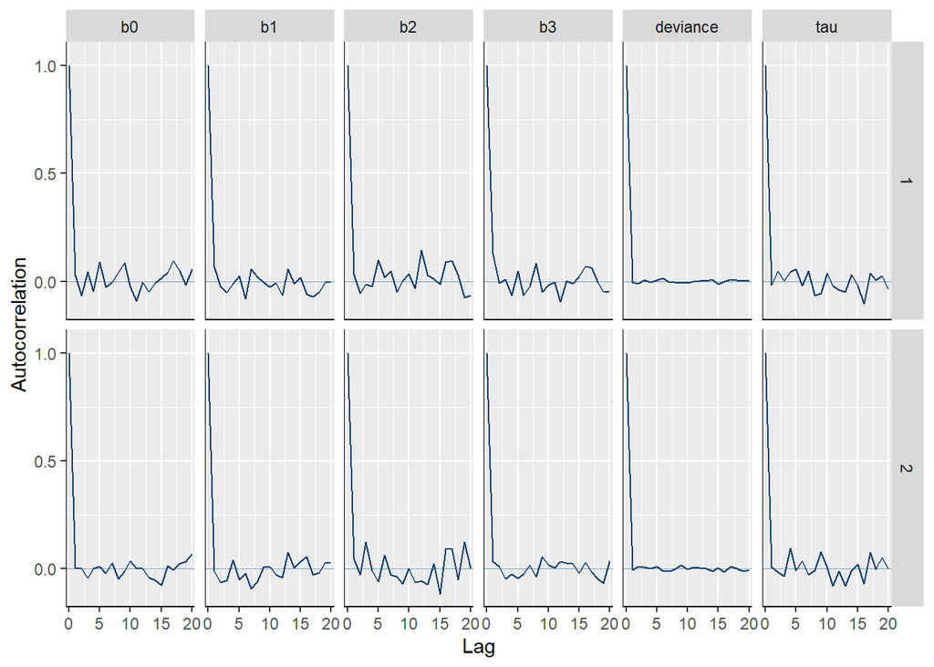

```r
chainArray<-linear_model$BUGSoutput$sims.array
bayesplot::mcmc_acf(chainArray)
```

```r
# Credible interval (HPD)

chainMat <- linear_model$BUGSoutput$sims.matrix
beta.HPD.jags <- coda::HPDinterval(as.mcmc(chainMat))
beta.HPD.jags
```

```
##                  lower         upper
## b0         -0.06668334    0.01567754
## b1          0.73598254    0.83349382
## b2         -0.10069004   -0.01228589
## b3          0.05937778    0.19387245
## deviance -873.40618845 -862.80911110
## tau        72.84645065   91.47489415
## attr(,"Probability")
## [1] 0.95
```

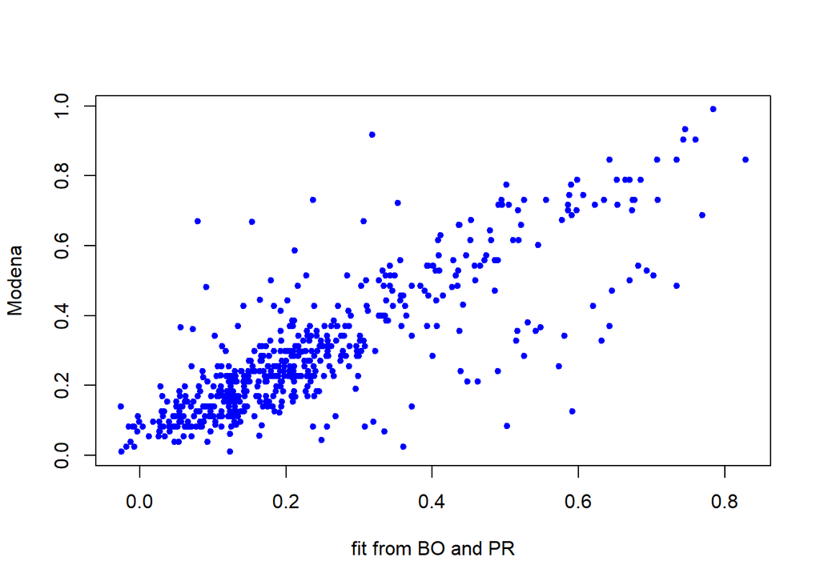

```r
# plot timeseries modena and fit
B0 <- mean(linear_model$BUGSoutput$sims.matrix[,1])
B1 <- mean(linear_model$BUGSoutput$sims.matrix[,2])
B2 <- mean(linear_model$BUGSoutput$sims.matrix[,3])
B3 <- mean(linear_model$BUGSoutput$sims.matrix[,4])
plot(B0 + B1*Modena_new_imput$pm25 + B2*Modena_new_imput$temperature + B3*Modena_new_imput$pressure, Modena_new_imput$pm10,   pch = 20, col = 'blue', cex = 1 , ylab = 'Modena', xlab = 'fit from BO and PR')
```

```r
cor(B0 + B1*Modena_new_imput$pm25 + B2*Modena_new_imput$temperature + B3*Modena_new_imput$pressure, Modena_new_imput$pm10)
```

```
## [1] 0.8181252
```